# Кластеризация и прогнозирование оттока клиентов фитнес-центра

**Описание и цели проекта:**\ Сеть фитнес-центров «Культурист-датасаентист» сталкивается с такой распространненой проблемой, как отток клиентов, и разрабатывает новую стратегию взаимодействия. Считается, что клиент попал в отток, если за последний месяц ни разу не посетил спортзал.

Цели проекта:

1. Разработать модель, прогнозирующую вероятность оттока (на уровне следующего месяца) для каждого клиента.
2. Выделить целевые группы клиентов, сформировать портрет для каждой группы.
3. Проанализировать основные признаки, наиболее сильно влияющие на отток
4. Разработать рекомендации по удержанию клиентов

**Задачи проекта:**

1. Изучить и провести предобработку данных: проверить пропуски, рассмотреть распределения.
2. Изучить значения признаков в разрезе по 2ум группам: тех, кто ушел в отток и тех, кто остался
3. Построить столбчатые гистограммы и распределения признаков для тех, кто ушёл (отток) и тех, кто остался (не попали в отток).
4. Построить матрицу корреляций.
5. Построить модуль бинарной классификации и обучить ее 2мя способами: логистической регрессией и случайным лесом.
6. Оценить метрики accuracy, precision и recall для обеих моделей на валидационной выборке, сравнить по ним модели
7. Постройте матрицу расстояний функцией и изобразить дендрограмму.
8. Провести кластеризацию клиентов на основании алгоритма K-Means
9. Изучить значения признаков каждого кластера и охарактеризовать их
10. Сформулировать основные выводы и предложить рекомендации для стратегии взаимодействия с клиентами и их удержания.

**Данные:** Заказчик подготовил данные по текущим клиентам, которые содержат основные характеристики клиента (пол, возраст, наличие телефона, дату первого обращения, отметку об участии в акции и др.), информацию о текущем статусе его абонемента, информацию из журнала посещений и покупок на месяц до оттока и факт оттока клиента на определённый месяц.

**Этапы проекта:**

1. Обзор и предобработка данных
2. Исследовательский анализ данных
3. Прогнозирование оттока клиентов
4. Кластерный анализ
5. Выводы и рекомендации

## Обзор и предобработка данных

```python
# Библиотеки
import pandas as pd
import numpy as np
import itertools

import matplotlib.pyplot as plt
import seaborn as sns

from scipy.cluster.hierarchy import dendrogram, linkage

from sklearn.preprocessing import StandardScaler
from sklearn.model_selection import train_test_split
from sklearn.linear_model import LogisticRegression
from sklearn.tree import DecisionTreeClassifier
from sklearn.ensemble import RandomForestClassifier, GradientBoostingClassifier
from sklearn.cluster import KMeans
from sklearn.metrics import confusion_matrix, accuracy_score, precision_score, recall_score, roc_auc_score, f1_score, plot_confusion_matrix,silhouette_score
```

```python
# Обзор данных
data = pd.read_csv('C:/Users/anita/datasets/Кластеризация и прогнозирование оттока/gym_churn.csv')
data.head(5)
```

|  | gender | Near_Location | Partner | Promo_friends | Phone | Contract_period | Group_visits | Age | Avg_additional_charges_total | Month_to_end_contract | Lifetime | Avg_class_frequency_total | Avg_class_frequency_current_month | Churn |
| --- | --- | --- | --- | --- | --- | --- | --- | --- | --- | --- | --- | --- | --- | --- |
| 0 | 1 | 1 | 1 | 1 | 0 | 6 | 1 | 29 | 14.227470 | 5.0 | 3 | 0.020398 | 0.000000 | 0 |
| 1 | 0 | 1 | 0 | 0 | 1 | 12 | 1 | 31 | 113.202938 | 12.0 | 7 | 1.922936 | 1.910244 | 0 |
| 2 | 0 | 1 | 1 | 0 | 1 | 1 | 0 | 28 | 129.448479 | 1.0 | 2 | 1.859098 | 1.736502 | 0 |
| 3 | 0 | 1 | 1 | 1 | 1 | 12 | 1 | 33 | 62.669863 | 12.0 | 2 | 3.205633 | 3.357215 | 0 |
| 4 | 1 | 1 | 1 | 1 | 1 | 1 | 0 | 26 | 198.362265 | 1.0 | 3 | 1.113884 | 1.120078 | 0 |

Наш набор данных включает следующие поля:

Данные клиента за предыдущий до проверки факта оттока месяц:\ 'gender' — пол;\ 'Near_Location' — проживание или работа в районе, где находится фитнес-центр;\ 'Partner' — сотрудник компании-партнёра клуба (сотрудничество с компаниями, чьи сотрудники могут получать скидки на абонемент — в таком случае фитнес-центр хранит информацию о работодателе клиента);\ Promo_friends — факт первоначальной записи в рамках акции «приведи друга» (использовал промо-код от знакомого при оплате первого абонемента);\ 'Phone' — наличие контактного телефона;\ 'Age' — возраст;\ 'Lifetime' — время с момента первого обращения в фитнес-центр (в месяцах).

Информация на основе журнала посещений, покупок и информация о текущем статусе абонемента клиента:\ 'Contract_period' — длительность текущего действующего абонемента (месяц, 6 месяцев, год);\ 'Month_to_end_contract' — срок до окончания текущего действующего абонемента (в месяцах);\ 'Group_visits' — факт посещения групповых занятий;\ 'Avg_class_frequency_total' — средняя частота посещений в неделю за все время с начала действия абонемента;\ 'Avg_class_frequency_current_month' — средняя частота посещений в неделю за предыдущий месяц;\ 'Avg_additional_charges_total' — суммарная выручка от других услуг фитнес-центра: кафе, спорттовары, косметический и массажный салон.\ 'Churn' — факт оттока в текущем месяце.

Большинство наименований столбцов в датафрейме начинаются с большой буквы. Это не очень удобно, поэтому переведем наименования в нижний регистр.

```python
# Переведем названия столбцов в нижний регистр
data.columns = data.columns.str.lower()
```

```python
# Изучим информацию о данных
data.info()
```

```
<class 'pandas.core.frame.DataFrame'>
RangeIndex: 4000 entries, 0 to 3999
Data columns (total 14 columns):
 #   Column                             Non-Null Count  Dtype
---  ------                             --------------  -----
 0   gender                             4000 non-null   int64
 1   near_location                      4000 non-null   int64
 2   partner                            4000 non-null   int64
 3   promo_friends                      4000 non-null   int64
 4   phone                              4000 non-null   int64
 5   contract_period                    4000 non-null   int64
 6   group_visits                       4000 non-null   int64
 7   age                                4000 non-null   int64
 8   avg_additional_charges_total       4000 non-null   float64
 9   month_to_end_contract              4000 non-null   float64
 10  lifetime                           4000 non-null   int64
 11  avg_class_frequency_total          4000 non-null   float64
 12  avg_class_frequency_current_month  4000 non-null   float64
 13  churn                              4000 non-null   int64
dtypes: float64(4), int64(10)
memory usage: 437.6 KB
```

Датафрейм содержит данные о 4000 клиентах. Пропусков нет. Все типы данных указаны корректно.  
Несмотря на то, что значения в столбцах gender, near_location, parther, promo_friends, phone, group_visits, churn скорее относятся к типу bool, в данном проекте под наши задачи мы оставим их в формате integer.

## Исследовательский анализ данных (EDA)

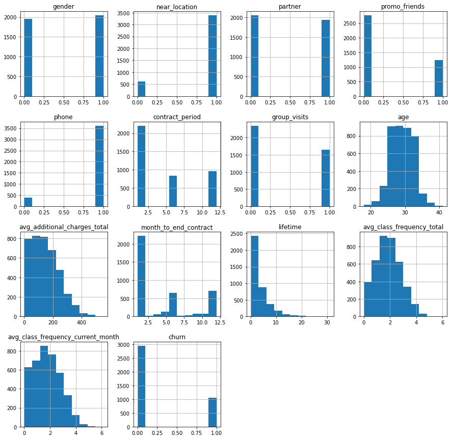

```python
# Изучим распределения в данных
data.hist(figsize=(15, 15));
```

Из гистограмм мы видим, что в данных нет аномальных значений и существенных выбросов.

```python
# Изучим распределения значений в столбцах более подробно
data.describe()
```

|  | gender | near_location | partner | promo_friends | phone | contract_period | group_visits | age | avg_additional_charges_total | month_to_end_contract | lifetime | avg_class_frequency_total | avg_class_frequency_current_month | churn |
| --- | --- | --- | --- | --- | --- | --- | --- | --- | --- | --- | --- | --- | --- | --- |
| count | 4000.000000 | 4000.000000 | 4000.000000 | 4000.000000 | 4000.000000 | 4000.000000 | 4000.000000 | 4000.000000 | 4000.000000 | 4000.000000 | 4000.000000 | 4000.000000 | 4000.000000 | 4000.000000 |
| mean | 0.510250 | 0.845250 | 0.486750 | 0.308500 | 0.903500 | 4.681250 | 0.412250 | 29.184250 | 146.943728 | 4.322750 | 3.724750 | 1.879020 | 1.767052 | 0.265250 |
| std | 0.499957 | 0.361711 | 0.499887 | 0.461932 | 0.295313 | 4.549706 | 0.492301 | 3.258367 | 96.355602 | 4.191297 | 3.749267 | 0.972245 | 1.052906 | 0.441521 |
| min | 0.000000 | 0.000000 | 0.000000 | 0.000000 | 0.000000 | 1.000000 | 0.000000 | 18.000000 | 0.148205 | 1.000000 | 0.000000 | 0.000000 | 0.000000 | 0.000000 |
| 25% | 0.000000 | 1.000000 | 0.000000 | 0.000000 | 1.000000 | 1.000000 | 0.000000 | 27.000000 | 68.868830 | 1.000000 | 1.000000 | 1.180875 | 0.963003 | 0.000000 |
| 50% | 1.000000 | 1.000000 | 0.000000 | 0.000000 | 1.000000 | 1.000000 | 0.000000 | 29.000000 | 136.220159 | 1.000000 | 3.000000 | 1.832768 | 1.719574 | 0.000000 |
| 75% | 1.000000 | 1.000000 | 1.000000 | 1.000000 | 1.000000 | 6.000000 | 1.000000 | 31.000000 | 210.949625 | 6.000000 | 5.000000 | 2.536078 | 2.510336 | 1.000000 |
| max | 1.000000 | 1.000000 | 1.000000 | 1.000000 | 1.000000 | 12.000000 | 1.000000 | 41.000000 | 552.590740 | 12.000000 | 31.000000 | 6.023668 | 6.146783 | 1.000000 |

Изучив распределения, мы можем сделать первые выводы о данных:

- Распределение по половому признаку почти 50/50.
- **Большинство клиентов находятся в возрасте 25-35 лет.** При этом в фитнес-клубе нет клиентов, старше 41 года.
- Логично, что **большинство клиентов (85%), выбравших данный фитнес-клуб, живут или работают в этом районе.**
- При этом **чуть меньше половины клиентов, является сотрудниками компаний-партнеров.**
- **Около трети всех клиентов пришли в рамках акции "Приведи друга"** (использовали промокод от знакомого при оплате первого абонемента).
- **Около 10%** клиентов при покупке абонемента **не оставили свой номера телефона.**
- В фитнес-клубе **можно приобрести абонемент длительностью только 1, 6 или 12 месяцев.**
- **Около 40% клиентов посещают групповые занятия.**
- **Половина клиентов впервые обратились в компанию менее 3х месяцев назад.** Есть небольшое количество клиентов (около 3%), обратившихся более года назад.
- **Выручка от других услуг фитнес-центра(кафе, массажи и пр) c одного клиента в 75% случаев не превышает 211 у.е.**
- **В среднем, большинство клиентов посещают зал около 2х раз в неделю.** При этом, сравнивая распределения кол-ва посещений за весь период и за последний месяц, мы видим, что за последний месяц выросла доля тех, кто ходил реже.
- **В фитнес-клубе действительно есть проблема с потерей клиентов. Около 27% клиентов фитнес-клуба ушли в отток, т.е. ни разу не посетили спортзал за последний месяц.**

Изучим взаимосвязи между всеми признаками и построим матрицу корреляции.

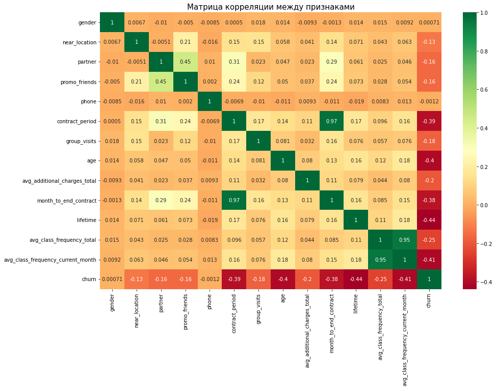

```python
# Построим хитмэп с матрицей корреляций между признаками
plt.figure(figsize=(15,10))
sns.heatmap(data.corr(), annot=True, cmap='RdYlGn')
plt.title('Матрица корреляции между признаками', fontsize=15);
```

**Выводы:** Из матрицы корреляции мы видим: 1) Отток клиентов точно не связан c такими признаками, как пол клиента(gender) и наличие номера телефона(phone).\ 2) Среди имеющихся у нас признаков, **сильнее всего отток клиентов коррелирует с признаком время с момента первого обращения клиента (lifetime), коэффициент составил -0.44. Это говорит о том, что в отток чаще попадают "новички"**, т.е. те, кто обратились в компанию недавно.\ 3) **С коэффициентом корреляции -0.41 отток клиентов связан со средним количеством посещений в неделю за последний в месяц. Это логично, чем чаще клиент посещает фитнес-клуб, тем меньше вероятность, что отвалится.** При этом среднее количество посещений в неделю за весь период абонемента влияет на вероятность оттока клиента в меньшей степени, т.е. клиент какое-то в течение абонемента может активно посещать занятия, но со временем перестать ходить.\ 4) Стоит отметить **корреляцию с коэффициентом -0.4 оттока и возраста клиента. Видимо, молодые клиенты бросают занятия чаще, чем клиенты более старшего возраста.**\ 5) **На отток клиента может влиять и длительность купленного им абонемента (коэффициент корреляции -0.39). Чаще всего отваливаются клиенты, купившие абонементы на самый маленький период (1 месяц).**\ 6) При этом **признак "длительность текущего купленного абонемента" тесно связан с признаком "количество месяцев до окончания действия абонемента". Это говорит о том, что в нашем датафрейме большое количество новичков, которые только купили абонемент (т.е. длительность абонемента равна периоду до его окончания).** Для нашей модели взаимная корреляция признаков нежелательна, поэтому мы оставим только один из них (длительность абонемента, т.к. его корреляция с целевой переменной выше).\ 7) Также мы видим **сильную корреляцию между столбцами среднее количество посещений в неделю за весь период абонемента и за последний месяц. Это говорит о том, что в целом посещаемость фитнес-клуба большинством клиентов стабильна.**

Изучим средние значения признаков в 2х группах - тех, кто ушел в отток и тех, кто остался.

```python
# Изучим характеристики клиентов в разрезе по ушедшим и оставшимся
churn_2 = data.groupby('churn').agg('mean').round(2).T
churn_2.columns =['Остались','Ушли']
churn_2
```

|  | Остались | Ушли |
| --- | --- | --- |
| gender | 0.51 | 0.51 |
| near_location | 0.87 | 0.77 |
| partner | 0.53 | 0.36 |
| promo_friends | 0.35 | 0.18 |
| phone | 0.90 | 0.90 |
| contract_period | 5.75 | 1.73 |
| group_visits | 0.46 | 0.27 |
| age | 29.98 | 26.99 |
| avg_additional_charges_total | 158.45 | 115.08 |
| month_to_end_contract | 5.28 | 1.66 |
| lifetime | 4.71 | 0.99 |
| avg_class_frequency_total | 2.02 | 1.47 |
| avg_class_frequency_current_month | 2.03 | 1.04 |

**Выводы:** В отток с одинаковой частотой попадают как мужчины, так и женщины. Также вероятность оттока, действительно никак не связана с наличием контактного номера телефона клиента. Эти признаки мы не будем брать для нашей модели прогнозирования вероятности оттока.

При этом мы, видим, что группы существенно отличаются между собой по таким признакам как:

- сотрудник компании-партнера клуба (среди отвалившихся клиентов, только 35,5% являются сотрудниками компани-партнера, в то время как среди оставшихся клиентов эта доля гораздо выше - 53,4%).
- участие в акции "приведи друга"
- дительность текущего абонемента (среди тех клиентов, кто ушел, средняя длительность абонемента 1,7 мес, в то время, как среди оставшихся средняя длительность - 5,7 мес)
- количество месяцев до окончания абонемента (как мы выявили выше, этот параметр тесно связан с длительностью абонемента)
- время с момента первого обращения (отваливаются преимущественно "новички", обратившиеся менее 2х месяцев назад)
- факт посещения групповых занятий (среди ушедших клиентов только 27% посетили хотя бы одно групповое занятие).
- среднее количество посещений в неделю за последний месяц и весь период действия абонемента (отвалившиеся клиенты за последний месяц в 2 раза реже, чем оставшиеся)

Визуализируем долю клиентов, ушедших в отток, для каждого признака.

```python
# Для визуализации округлим значения среднего количества посещения в неделю за весь период и месяц
data['round_frequency_total'] = data['avg_class_frequency_total'].round(0)
data['round_frequency_month'] = data['avg_class_frequency_current_month'].round(0)

# Разделим на сегменты клиентов по тратам на доп услуги фитнес-клуба
add_check = [0,50,100,150,200,250,300,600]
data['check'] = pd.cut(data['avg_additional_charges_total'], add_check, include_lowest=True)
```

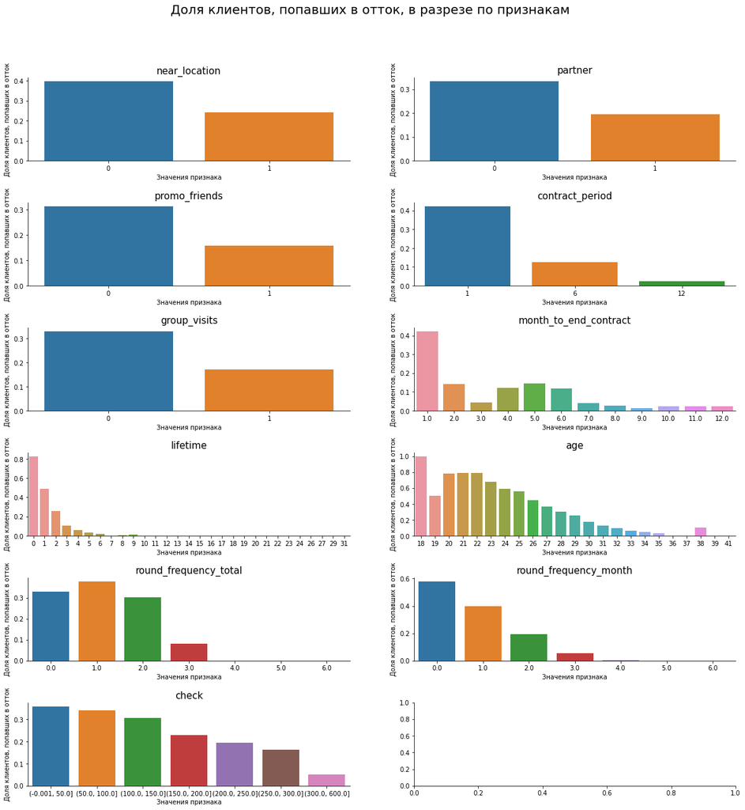

```python
# Выберем признаки для отображения столбчатых диаграм
features = ['near_location', 'partner', 'promo_friends', 'contract_period', 'group_visits', 'month_to_end_contract', 'lifetime', 'age','round_frequency_total', 'round_frequency_month','check']

# Расположим все диаграммы в 2 столбца
num_cols = 2

# Рассчитаем нужное количество строк
if len(features)%num_cols == 0:
    num_rows = len(features)//num_cols
else:
    num_rows = (len(features)//num_cols) + 1

# Определим фигуру и оси
fig, ax = plt.subplots(figsize=(20,20),
                       nrows=num_rows,
                       ncols=num_cols)

# Добавим общее название
fig.suptitle('Доля клиентов, попавших в отток, в разрезе по признакам',
             fontsize=20)

# Напишем цикл для построения столбчатых диаграмм
for feat in features:
    row = features.index(feat)//num_cols
    col = features.index(feat)%num_cols
    table = data.groupby([feat])[['churn']].agg('mean').reset_index()
    sns.barplot(data = table, x=feat, y='churn', ax = ax[row][col])
    ax[row][col].set_title(feat, fontsize=15)
    ax[row][col].set_ylabel('Доля клиентов, попавших в отток')
    ax[row][col].set_xlabel('Значения признака')
    sns.despine()


plt.subplots_adjust(top=0.9, wspace=0.2, hspace=0.5)
```

**Выводы:**

1. Таким образом, **чаще всего в отток попадают недавно обратившиеся клиенты (lifetime 0-1), купившие абонемент на 1 месяц.** Возможно, эти клиенты "хотели начать новую жизнь с понедельника" и просто забросили эту идею, так ни разу и не сходив. Или, купив абонемент и посетив 1 раз зал, поняли, что им не нравится и решили сменить фитнес-клуб. **Учитывая, что продажи абонементов, длительностью всего 1 месяц, составляют более половины всех продаж (в количественном выражении), регулярный отток 40% таких клиентов очень критичен.**

В качестве рекомендации **фитнес-клубу стоит рассмотреть возможность внедрения абонементов длительностью 3 месяца** (по гораздо более выгодной цене в пересчете на 1 месяц и/или одновременно при этом увеличить стоимость 1-месячного абомента) и агитировать новых клиентов приобретать более длительный абонемент. В таком случае, вероятность того, что за 3 месяца клиент все-таки дойдет до занятий, привыкнет, освоится и по окончанию 3х месяцев продлит абонемент будет выше. Также помочь клиенту освоится в зале может акция при покупке абонемента сроком более 3х месяцев "бесплатная персональная тренировка".

**Среди клиентов, которые приобреют долгосрочные абонементы (6-12 месяцев), отток в несколько раз ниже.** Для точного понимания, небходимо изучить текущее ценообразование на абонементы, но в качестве гипотезы можно предположить, что увеличив цену на 1-месячный абонемент и, сохранив/снизив стоимость долгосрочных абонементов, ситуация с оттоком улучшится без потери в выручке.

1. **Высокий отток (около 80%) наблюдается среди клиентов 18-22 года.** Таких клиентов немного, доля этой аудитории составляет менее 2%. **Скорее всего, это просто не целевая аудитория этого фитнес-клуба. При этом среди клиентов старше 30 лет отток низкий и отсутствует совсем.**

## Прогнозирование оттока клиентов

Построим модель бинарной классификации, прогнозирующую вероятность оттока для каждого клиента.

Обучим ее несколькими способами (логистическая регрессия, дерево решений, случайный лес, градиентный бустинг) и на основании метрик (accuracy, precision и recall) выберем лучшую.

На основании матрицы корреляции для нашей модели мы возьмем следующие признаки клиента:

```python
# Отберем признаки для построения модели
X = (
    data[['age', 'near_location','contract_period','lifetime','avg_class_frequency_current_month', 'partner',
          'promo_friends','group_visits']]
)

y = data['churn']
```

```python
# Разделим данные на обучающую и валидационную выборку
X_train, X_test, y_train, y_test = train_test_split(X,y, test_size=0.2, random_state=0)

# Стандартизируем данные
scaler = StandardScaler()
X_train_st = scaler.fit_transform(X_train)
X_test_st = scaler.transform(X_test)
```

```python
# Подготовим список моделей
models = [
    LogisticRegression(solver='liblinear'),
    DecisionTreeClassifier(),
    RandomForestClassifier(n_estimators=100),
    GradientBoostingClassifier(n_estimators=100)
]

# Напишем функцию, принимающую на вход модель и вычисляющая метрики
def make_predictions(m, X_train_st, y_train, X_test_st, y_test):
    model = m
    model.fit(X_train_st, y_train)
    y_pred = m.predict(X_test_st)
    print(
        'Доля правильных ответов(accuracy_score):{:.2f} \nТочность(precision):{:.2f} \nПолнота(recall):{:.2f} \nf1-мера:{:.2f}'.format(
            accuracy_score(y_test, y_pred),
            precision_score(y_test, y_pred),
            recall_score(y_test, y_pred),
            f1_score(y_test, y_pred),
        )
    )
```

```python
# Цикл, которые вывод метрики по списку моделей
for m in models:
    print('Метрики модели', m),
    make_predictions(m, X_train_st, y_train, X_test_st, y_test)
    print('')
```

```
Метрики модели LogisticRegression(solver='liblinear')
Доля правильных ответов(accuracy_score):0.90
Точность(precision):0.79
Полнота(recall):0.82
f1-мера:0.80

Метрики модели DecisionTreeClassifier()
Доля правильных ответов(accuracy_score):0.87
Точность(precision):0.72
Полнота(recall):0.76
f1-мера:0.74

Метрики модели RandomForestClassifier()
Доля правильных ответов(accuracy_score):0.89
Точность(precision):0.79
Полнота(recall):0.77
f1-мера:0.78

Метрики модели GradientBoostingClassifier()
Доля правильных ответов(accuracy_score):0.89
Точность(precision):0.79
Полнота(recall):0.77
f1-мера:0.78
```

Таким образом, **лучшие метрики показывает модель логистической регрессии.\ Эта модель "угадала" 90% правильных ответов** (как среди оставшихся, так и среди ушедших).\ Также у модели логистической регрессии самый высокий показатель recall (полнота). В данном проекте показатель recall (полнота) для нас важнее precision (точность). Лучше заведомо считать, что клиент с высокой вероятностью уйдет и успеть применить для этого какие-то меры (отправить смс или пуш-уведомление с напоминанием, предложить скидку на продление абонемента или подарок из списка дополнительных услуг), чем пропустить такие ситуации.

Выберем модель логистической регрессии в качестве основной. Обучим ее еще раз, изучим матрицу ошибок и попробуем увеличить метрики модели с помощью порога вероятности.

```python
# Проведем обучение выбранной модели
model = LogisticRegression(solver='liblinear')
model.fit(X_train_st, y_train)
y_pred = m.predict(X_test_st)

# Построим матрицу ошибок
cm = confusion_matrix(y_test, y_pred)
tn,fp,fn,tp = cm.ravel()
print(
    'Матрица ошибок модели логистической регрессии:','\n',
    'True Negative:', tn,'\n',
    'False Positive:', fp,'\n',
    'False Negaive:',fn,'\n',
    'True Positive:', tp,
)
```

```
Матрица ошибок модели логистической регрессии:
 True Negative: 562
 False Positive: 40
 False Negaive: 45
 True Positive: 153
```

```python
# Рассчитаем вероятности, согласно которой модель относит клиента к определенному классу
probabilities = model.predict_proba(X_test_st)[:,1]

# Снова выведем все метрики модели
print('Метрики при автоматическом прогнозе:')
print('ROC_AUC: {:.2f}'.format(roc_auc_score(y_test, probabilities)))
print(
        'Доля правильных ответов(accuracy_score):{:.2f} \nТочность(precision):{:.2f} \nПолнота(recall):{:.2f} \nf1-мера:{:.2f}'.format(
            accuracy_score(y_test, y_pred),
            precision_score(y_test, y_pred),
            recall_score(y_test, y_pred),
            f1_score(y_test, y_pred),
        )
    )

# Зададим порог
threshold = 0.4

# На основании вероятности рассчитаем, к какому классу относится каждый клиент
custom_predictions = [0 if i < threshold else 1 for i in probabilities]

# Выведем все метрики для прогноза по новому порогу
print('\n')
print('Метрики для прогноза с кастомным порогом 0.4:')
print('ROC_AUC: {:.2f}'.format(roc_auc_score(y_test, custom_predictions)))
print(
        'Доля правильных ответов(accuracy_score):{:.2f} \nТочность(precision):{:.2f} \nПолнота(recall):{:.2f} \nf1-мера:{:.2f}'.format(
            accuracy_score(y_test, custom_predictions),
            precision_score(y_test, custom_predictions),
            recall_score(y_test, custom_predictions),
            f1_score(y_test, custom_predictions),
        )
    )

# Построим матрицу ошибок по новому прогнозу
cm = confusion_matrix(y_test, custom_predictions)
tn,fp,fn,tp = cm.ravel()
print('\n')
print(
    'Матрица ошибок с кастомным порогом:','\n',
    'True Negative:', tn,'\n',
    'False Positive:', fp,'\n',
    'False Negaive:',fn,'\n',
    'True Positive:', tp,
)
```

```
Метрики при автоматическом прогнозе:
ROC_AUC: 0.96
Доля правильных ответов(accuracy_score):0.89
Точность(precision):0.79
Полнота(recall):0.77
f1-мера:0.78


Метрики для прогноза с кастомным порогом 0.4:
ROC_AUC: 0.88
Доля правильных ответов(accuracy_score):0.90
Точность(precision):0.75
Полнота(recall):0.86
f1-мера:0.80


Матрица ошибок с кастомным порогом:
 True Negative: 545
 False Positive: 57
 False Negaive: 27
 True Positive: 171
```

Таким образом, изменив порог, при котором клиент считается перешедшим в отток, до 0.4, показатель полноты (recall) вырос до 0.86. Доля правильных ответов (accuracy) при этом осталась на уровне 90%.

**Модель правильно определила 171 (из 198) отвалившихся клиентов и 545 (из оставшихся). Модель стала чаще "ложно срабатывать"(снизился показатель точность (precision)), но в данном проекте показатель recall (полнота) для нас важнее.** Лучше заведомо считать, что клиент с высокой вероятностью уйдет и успеть применить для этого какие-то меры, чем пропустить такие ситуации.

Посмотрим, какие характеристики клиента, модель посчитала наиболее важными:

```python
# Cоздадим датафрейм с именами признаков и их важностью и выведем его по убыванию важности
display(pd.DataFrame({'features':X_train.columns, 'importances':model.coef_.flatten()}).sort_values(by='importances'))
```

|  | features | importances |
| --- | --- | --- |
| 3 | lifetime | -3.761642 |
| 2 | contract_period | -1.333311 |
| 4 | avg_class_frequency_current_month | -1.289360 |
| 0 | age | -1.082226 |
| 7 | group_visits | -0.359774 |
| 6 | promo_friends | -0.247806 |
| 1 | near_location | -0.077338 |
| 5 | partner | -0.039423 |

**Наиболее важными признаками при прогнозировании оттока клиента** модель посчитала время с момента первого обращения(lifetime), длительность абонемента(contract_period), среднее количество посещений в неделю за последний месяц(avg_class_frequency_current_month) и возраст клиента(age).\ Это согласуется с коэффициентами корреляции модели и теми выводами, которые мы сделали ранее. Значит, наша модель работает адекватно.

## Кластерный анализ

Проведем кластеризацию клиентов по методу K-Means, изучим характеристики и опишем получившиеся результаты. Посмотрим, какие кластеры склонны к оттоку, а какие - надежны.

Согласно ТЗ, полученному от Заказчика, нам нужно выделить 5 кластеров. Но мы также проверим, на какое количество кластеров предложит разделить дендрограмма и коэффициент Silhouette.

Для модели кластеризации мы возьмем все имеющиеся у нас признаки, кроме переменной с фактом оттока клиента, сегментированными тратами на дополнительные услуги клуба и округленные значения по кол-ву посещений в неделю (т.к. мы их формировали отдельно под построение диаграмм).

```python
# Подготовим данные, удалим столбец с оттоком, сегментированным тратами и округленным кол-вом посещений в неделю
X = data.drop(columns=['churn','check','round_frequency_total','round_frequency_month'], axis=1)
```

```python
# Стандартизируем данные
sc = StandardScaler()
X_sc = sc.fit_transform(X)
```

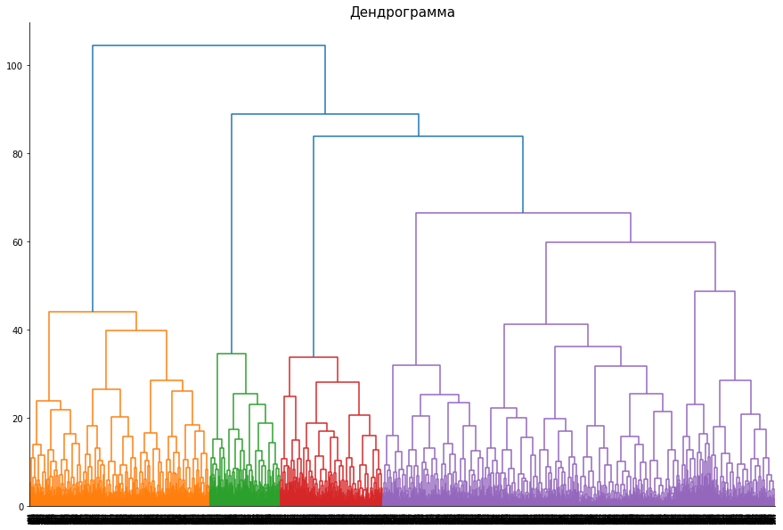

```python
# Построим матрицу расстояний и нарисуем дендрограмму
linked = linkage(X_sc, method = 'ward')

plt.figure(figsize=(15,10))
dendrogram(linked, orientation='top')
plt.title('Дендрограмма', fontsize=15)
sns.despine()
plt.show()
```

Дендрограмма предлагает нам разделить всех клиентов на 4 кластера.\ Посмотрим, какое количество кластеров можно выделить по метрике Silhouette.

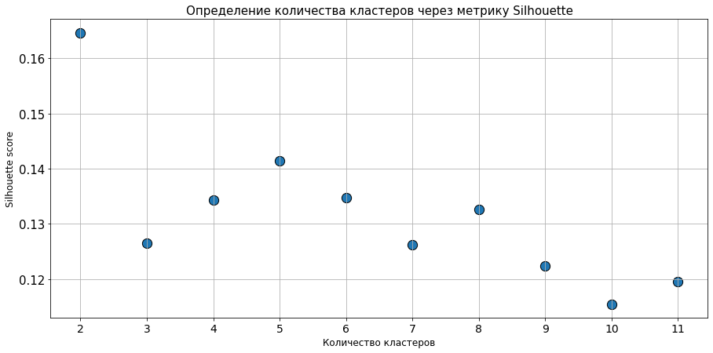

```python
# Расчет оптимального количества кластеров через силуэт
km_silhouette = []

for i in range(2,12):
    km = KMeans(n_clusters=i, random_state=0).fit(X_sc)
    preds = km.predict(X_sc)
    silhouette = silhouette_score(X_sc,preds)
    km_silhouette.append(silhouette)

plt.figure(figsize=(15,7))
plt.title('Определение количества кластеров через метрику Silhouette',fontsize=15)
plt.scatter(x=[i for i in range(2,12)], y=km_silhouette, s=150, edgecolor='k')
plt.grid(True)
plt.xlabel("Количество кластеров",fontsize=12)
plt.ylabel("Silhouette score",fontsize=12)
plt.xticks([i for i in range(2,12)],fontsize=14)
plt.yticks(fontsize=15)
plt.show()
```

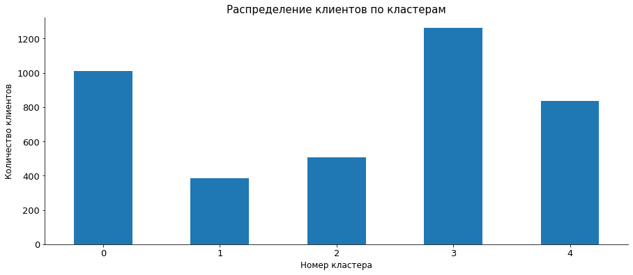

```python
# Построим модель
km = KMeans(n_clusters=5, random_state=0)
labels = km.fit_predict(X_sc)

# Добавим разделение на кластеры в исходную таблицу
data['cluster'] = labels

# Посмотрим распределение клиентов по кластерам
plt.figure(figsize=(15,6))
data.groupby('cluster')['gender'].agg('count').plot(kind='bar')
plt.title('Распределение клиентов по кластерам', fontsize=15)
plt.ylabel('Количество клиентов', fontsize=12)
plt.xlabel('Номер кластера', fontsize=12)
plt.xticks(rotation=0, fontsize=13)
plt.yticks(fontsize=13)
sns.despine();
```

Разделение клиентов на кластеры проведено, в исходный датафрейм мы также добавили номер кластера, к которому относится клиент.\ Наибольшее количество клиентов находится в кластерах 3 и 0 - 1262 и 1010 человек соответственно.\ Еще 838 клиентов в кластере 4.\ Самые малочисленные получились кластеры 2 и 1 - 505 и 385 клиентов соответственно.

Изучим особенности каждого кластера.

```python
# Изучим средние значения признаков для каждого кластера и выделим максимальные и минимальные значения
table = data.groupby('cluster').mean().T
table.style.highlight_max(color='yellowgreen', axis=1).highlight_min(color='coral', axis=1).format('{:.2f}')
```

| cluster | 0 | 1 | 2 | 3 | 4 |
| --- | --- | --- | --- | --- | --- |
| gender | 0.50 | 0.52 | 0.50 | 0.49 | 0.56 |
| near_location | 0.96 | 0.86 | 0.00 | 1.00 | 0.98 |
| partner | 0.78 | 0.47 | 0.46 | 0.35 | 0.36 |
| promo_friends | 0.57 | 0.31 | 0.08 | 0.24 | 0.23 |
| phone | 1.00 | 0.00 | 1.00 | 1.00 | 1.00 |
| contract_period | 10.89 | 4.79 | 2.35 | 1.95 | 2.67 |
| group_visits | 0.54 | 0.43 | 0.22 | 0.34 | 0.47 |
| age | 29.98 | 29.30 | 28.48 | 28.17 | 30.13 |
| avg_additional_charges_total | 160.76 | 143.96 | 135.46 | 131.62 | 161.66 |
| month_to_end_contract | 9.95 | 4.48 | 2.20 | 1.86 | 2.46 |
| lifetime | 4.74 | 3.92 | 2.81 | 2.44 | 4.90 |
| avg_class_frequency_total | 1.98 | 1.85 | 1.66 | 1.25 | 2.85 |
| avg_class_frequency_current_month | 1.97 | 1.72 | 1.48 | 1.01 | 2.85 |
| churn | 0.03 | 0.27 | 0.44 | 0.51 | 0.07 |
| round_frequency_total | 1.99 | 1.85 | 1.65 | 1.24 | 2.85 |
| round_frequency_month | 1.98 | 1.71 | 1.47 | 1.01 | 2.84 |

Из таблицы выше мы видим, что каждый кластер имеет свои особенности и можем присвоить им названия.

**Кластер 0 - Покупатели годовых абонементов** (1010 клиентов, доля кластера - 25,3%). Средняя длительность приобретенного абоенемента клиентами этой группы - почти 11 месяцев. Клиенты из этого кластера живут или работают рядом с фитнес-клубом. При этом чаще всего являются сотрудниками компаний-партнеров. При покупке абонемента также часто используют промокод от друзей. Т.е. в большинстве случаев абонемент покупают со скидкой. В среднем, клиенты этого кластера впервые обратились около 5 месяцев назад. Посещают клуб 2 раза в неделю, при этом активно ходят на групповые занятия и пользуются дополнительными услугами клуба (массаж, кафе и т.д.). **Это самая лояльная группа клиентов, отток в этом кластере составляет всего 3%.**

**Кластер 1 - Инкогнито** (385 клиентов, доля кластера - 9,6%). Данный кластер получила такое название, поскольку в нем находятся клиенты, которые препочли не оставлять свой номер телефона. При этом они также достаточно часто приобретают долгосрочные абонементы. Средняя склонность к оттоку 27%. Это самый маленький кластер. **Чтобы заполучить их контактные данные для дальнейшей коммуникации и удержания клиентов им можно сделать какой-то подарок, например, предложив что-то из дополнительных услуг (персональную тренировку, массаж) и попросить оставить телефон, под предлогом, что тренер/массажист позвонит и договорится с ними о времени.**

**Кластер 2 - Жители других районов** (505 клиентов, доля кластера - 12,6%). Клиенты этого кластера живут и работают в других локациях. 46% клиентов из этой группы являются сотрудниками компаний-партнеров, что, видимо, и стало причиной покупки абонемента в этом фитнес-клубе, т.к. промокод от друга они практически не используют. Посещают фитнес-клуб 1-2 раза в неделю, но редко ходят на групповые занятия. Среди этой группы большая доля клиентов, которые обратились в фитнес-клуб недавно. Как следствие, **в этом кластере достаточно высокий уровень оттока по сравнению с другими кластерами- 44%, клиентам неудобно здесь заниматься и, возможно, это просто нецелевая аудитория нашего фитнес-клуба. Удержать таких клиентов могут только уникальные преимущества, которые они не смогут найти в фитнес-клубах своего района** (профессиональная квалификация тренеров, уникальные тренажеры и спа-зона) - для понимания таких факторов, необходимо дополнительное маркетинговое исследование. Также, поскольку они почти не используют промокод от друзей, им можно предложить более выгодные условия для этой программы и адаптировать ее условия под эту группу (например, Акция "Семейный абонемент"), наличие "компании" также может повлиять на размер оттока в этой группе, компенсируя фактор, что приходится ездить в другой район.

**Кластер 3 - Новые клиенты** (1262 клиента, доля кластера - 31,6%). **Самый большой кластер и при этом первоочередной, с которым необходимо активно работать в настоящее время. Это новые клиенты, покупающие преимущественно 1-месячные абонементы.** При этом 100% клиентов этого кластера живут или работают в том же районе. Возможно, эти клиенты "хотели начать новую жизнь с понедельника" и просто забросили эту идею, так ни разу и не сходив. Или, купив абонемент и посетив 1 раз зал, поняли, что им не нравится и решили сменить фитнес-клуб. **Это наиболее всего подверженная оттоку группа - отток 50%.**\ **Для снижения оттока в этом кластере можно порекомендовать разработать специальную систему "онбординга" клиента** - рассказать ему все детали, особенности и лучшие практики, помочь ему адаптироваться в клубе и понять, как фитнес-клуб поможет достичь ему своей цели. Какие есть групповые занятия, к какому тренеру по какому вопросу можно обратиться, какие спортовары можно приобрести для увеличения эффективности. Можно раз в неделю организовывать специальные групповые мастер-классы для новичков, где тренер будет рассказывать про тренажеры, делится секретами успеха, ставить технику выполнения упражнений. Для увеличения частоты посещений можно ввести соревновательный момент - подарок/скидка/баллы на доп услуги за самую активную посещаемость, за лучшее "до и после", за какие-то спортивные показатели. Все это поможет клиенту адаптироваться и проникнуться идеей спортивного образа жизни.\ В качестве другой рекомендации фитнес-клубу стоит **рассмотреть возможность внедрения абоментов длительностью 3 месяца** (по гораздо более выгодной цене в пересчете на 1 месяц и/или одновременно при этом увеличить стоимость 1-месячного абомента) и агитировать новых клиентов приобретать более длительный абонемент. В таком случае, также вероятность того, что за 3 месяца клиент все-таки дойдет до занятий, привыкнет, освоится и по окончанию 3х месяцев продлит абонемент будет выше. Поскольку это более рентабельный абонемент, в данном случае помимо "мастер-классов" для новичков, помочь клиенту освоится в зале может акция "бесплатная персональная тренировка".

**Кластер 4 - Постоянные клиенты.** (838 клиентов, доля кластера - 20,9%). **Клиенты этого кластера также предпочитают 1-месячные абонементы, но в отличие от кластера 3 (новые клиенты), их продлевают и активно занимаются.** Это один из самых ценных кластеров компании. Это клиенты, которые помимо активной посещаемости (около 3х раз в неделю), также активно приобретают и дополнительные услуги фитнес-клуба. Это "надежная" группа, отток клиентов в которой составляет всего 7%. Тем не менее, **для таких клиентов рекомендуется разработать программу лояльности - скидка/подарок за каждое последующее продление, или "каждый 10-й массаж бесплатно", или особые условия для приобретения долгосрочного абонемента. Возможно, этим клиентам также подошел бы абонемент продолжительностью 3 месяца** (поскольку на данный момент они предпочитают 1-месячные абонементы и по каким-то причинам не хотят покупать абонементы на 6-12 месяцев).

```python
# Добавим в датафрейм названия кластеров
data['cluster_name'] = data['cluster'].map(
    {0: '0. Пок-ли год. абон.',
     1: '1. Инкогнито',
     2: '2. Жители др районов',
     3: '3. Новые клиенты',
     4: '4. Постоянные клиенты'}
)
```

Построим распределения признаков в разрезе по каждому кластеру.

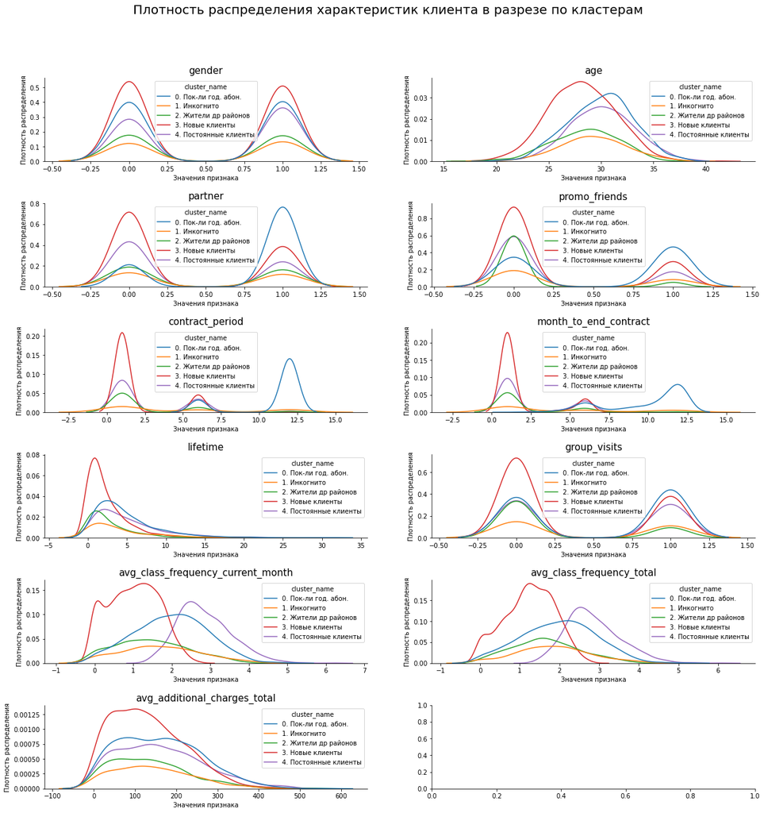

```python
# Отберем признаки для диаграмм распределения
features = (
    ['gender','age','partner','promo_friends','contract_period','month_to_end_contract',
     'lifetime','group_visits','avg_class_frequency_current_month', 'avg_class_frequency_total', 'avg_additional_charges_total']
)

# Расположим все диаграммы в 2 столбца
num_cols = 2

# Рассчитаем нужное количество строк
if len(features)%num_cols == 0:
    num_rows = len(features)//num_cols
else:
    num_rows = (len(features)//num_cols) + 1

# Определим фигуру и оси
fig, ax = plt.subplots(figsize=(20,20),
                       nrows=num_rows,
                       ncols=num_cols)

# Добавим общее название
fig.suptitle('Плотность распределения характеристик клиента в разрезе по кластерам',
             fontsize=20)

# Напишем цикл для построения диаграмм
for feat in features:
    row = features.index(feat)//num_cols
    col = features.index(feat)%num_cols
    data = data.sort_values(by='cluster')
    sns.kdeplot(data=data, x=feat, hue='cluster_name', palette='tab10', ax = ax[row][col])
    ax[row][col].set_title(feat, fontsize=15)
    ax[row][col].set_ylabel('Плотность распределения')
    ax[row][col].set_xlabel('Значения признака')
    sns.despine()


plt.subplots_adjust(top=0.9, wspace=0.2, hspace=0.5)
```

**Вывод:** Таким образом, все графики распределения подтверждают все наши выводы, сделанные на шаге ранее.

Для более подробного изучения распределения построим также ящики с усами для всех непрерывных признаков +возраст и время с момента первого обращения и столбчатые диаграммы для бинарных признаков + длительность абонемента.

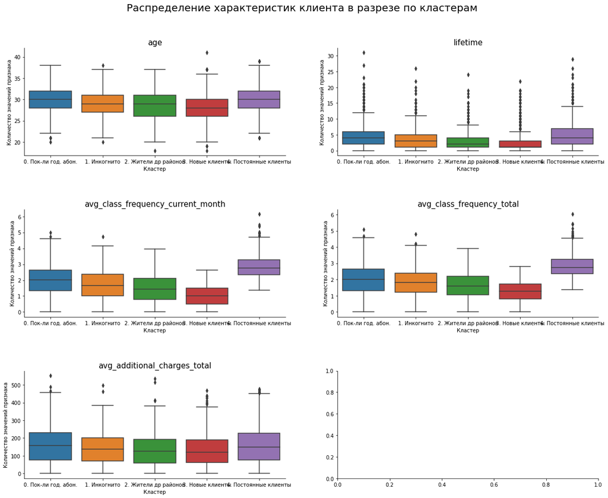

```python
# Отберем признаки для ящиков с усами
features = (
    ['age','lifetime','avg_class_frequency_current_month',
     'avg_class_frequency_total', 'avg_additional_charges_total']
)

# Расположим все диаграммы в 2 столбца
num_cols = 2

# Рассчитаем нужное количество строк
if len(features)%num_cols == 0:
    num_rows = len(features)//num_cols
else:
    num_rows = (len(features)//num_cols) + 1

# Определим фигуру и оси
fig, ax = plt.subplots(figsize=(20,15),
                       nrows=num_rows,
                       ncols=num_cols)

# Добавим общее название
fig.suptitle('Распределение характеристик клиента в разрезе по кластерам',
             fontsize=20)

# Напишем цикл для построения диаграмм
for feat in features:
    row = features.index(feat)//num_cols
    col = features.index(feat)%num_cols
    data = data.sort_values(by='cluster')
    sns.boxplot(data=data, y=feat, x='cluster_name', palette='tab10', ax = ax[row][col])
    ax[row][col].set_title(feat, fontsize=15)
    ax[row][col].set_ylabel('Количество значений признака')
    ax[row][col].set_xlabel('Кластер')
    sns.despine()


plt.subplots_adjust(top=0.9, wspace=0.2, hspace=0.5)
```

Из диаграмм boxplot мы еще раз наглядно видим различия в посещаемости фитнес-клуба между кластерами 3.Новые клиенты (низкая) и 4.Постоянные клиенты (самый активный кластер).

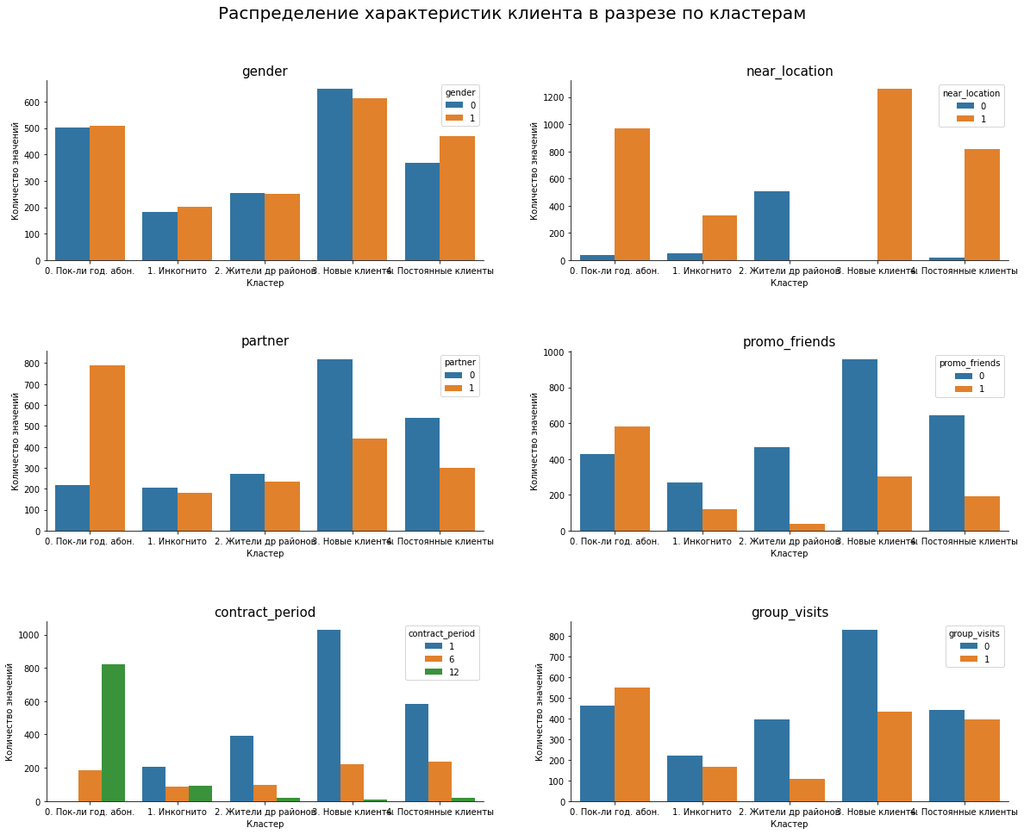

```python
# Отберем признаки для столбчатых диаграмм
features = (
    ['gender','near_location','partner','promo_friends','contract_period', 'group_visits']
)

# Расположим все диаграммы в 2 столбца
num_cols = 2

# Рассчитаем нужное количество строк
if len(features)%num_cols == 0:
    num_rows = len(features)//num_cols
else:
    num_rows = (len(features)//num_cols) + 1

# Определим фигуру и оси
fig, ax = plt.subplots(figsize=(20,15),
                       nrows=num_rows,
                       ncols=num_cols)

# Добавим общее название
fig.suptitle('Распределение характеристик клиента в разрезе по кластерам',
             fontsize=20)

# Напишем цикл для построения диаграмм
for feat in features:
    row = features.index(feat)//num_cols
    col = features.index(feat)%num_cols
    bars = data.groupby([feat,'cluster_name']).agg({'check': 'count'}).sort_values(by=['cluster_name',feat]).reset_index()
    sns.barplot(data=bars, x='cluster_name', y='check',  hue = feat, palette='tab10', ax = ax[row][col])
    ax[row][col].set_title(feat, fontsize=15)
    ax[row][col].set_ylabel('Количество значений')
    ax[row][col].set_xlabel('Кластер')
    sns.despine()


plt.subplots_adjust(top=0.9, wspace=0.2, hspace=0.5)
```

Столбчатые диаграммы также подтверждают все сделанные нами выводы на предыдущих этапах:

## Выводы и рекомендации

В данном проекте мы проанализировали данные о 4000 клиентов фитнес-клуба и по результатам можем сделать следующие выводы:

**1.** В первом разделе мы **провели предобработку данных** Выявили, что пропусков нет и все типы данных указаны корректно. Для дальнейшего удобства мы первели названия всех столбцов в нижий регистр.

**2. По результатам исследовательского анализа мы выявили:**

- **Большинство клиентов находятся в возрасте 25-35 лет.** При этом в фитнес-клубе нет клиентов, старше 41 года.
- Логично, что **большинство клиентов (85%), выбравших данный фитнес-клуб, живут или работают в этом районе.**
- При этом **чуть меньше половины клиентов, является сотрудниками компаний-партнеров.**
- **Около трети всех клиентов пришли в рамках акции "Приведи друга"** (использовали промокод от знакомого при оплате первого абонемента).
- **Около 10%** клиентов при покупке абонемента **не оставили свой номера телефона.**
- В фитнес-клубе **можно приобрести абонемент длительностью только 1, 6 или 12 месяцев.**
- **Около 40% клиентов посещают групповые занятия.**
- **Половина клиентов впервые обратились в компанию менее 3х месяцев назад.** Есть небольшое количество клиентов (около 3%), обратившихся более года назад.
- **Выручка от других услуг фитнес-центра(кафе, массажи и пр) c одного клиента в 75% случаев не превышает 211 у.е.**
- **В среднем, большинство клиентов посещают зал около 2х раз в неделю.** При этом, сравнивая распределения кол-ва посещений за весь период и за последний месяц, мы видим, что за последний месяц выросла доля тех, кто ходил реже.
- **В фитнес-клубе действительно есть проблема с потерей клиентов. Около 27% клиентов фитнес-клуба ушли в отток, т.е. ни разу не посетили спортзал за последний месяц.**

**3. Мы построили матрицу корреляций и рассмотрели влияние каждого признака** на отток клиента и как они взаимосвязаны между собой.

- Среди имеющихся у нас признаков, **сильнее всего отток клиентов коррелирует с признаком время с момента первого обращения клиента (lifetime), коэффициент составил -0.44. Это говорит о том, что в отток чаще попадают "новички"**, т.е. те, кто обратились в компанию недавно.
- **С коэффициентом корреляции -0.41 отток клиентов связан со средним количеством посещений в неделю за последний в месяц. Это логично, чем чаще клиент посещает фитнес-клуб, тем меньше вероятность, что отвалится.** При этом среднее количество посещений в неделю за весь период абонемента влияет на вероятность оттока клиента в меньшей степени, т.е. клиент какое-то в течение абонемента может активно посещать занятия, но со временем перестать ходить.
- Стоит отметить **корреляцию с коэффициентом -0.4 оттока и возраста клиента. Молодые клиенты бросают занятия чаще, чем клиенты более старшего возраста.**
- **На отток клиента может влиять и длительность купленного им абонемента (коэффициент корреляции -0.39). Чаще всего отваливаются клиенты, купившие абонементы на самый маленький период (1 месяц).**

**4. Таким образом, чаще всего в отток попадают недавно обратившиеся клиенты (lifetime 0-1), купившие абонемент на 1 месяц.** Возможно, эти клиенты "хотели начать новую жизнь с понедельника" и просто забросили эту идею, так ни разу и не сходив. Или, купив абонемент и посетив 1 раз зал, поняли, что им не нравится и решили сменить фитнес-клуб. **Учитывая, что продажи абонементов, длительностью всего 1 месяц, составляют более половины всех продаж (в количественном выражении), регулярный отток 40% таких клиентов очень критичен.**

**5. Высокий отток (около 80%) наблюдается среди клиентов 18-22 года. Таких клиентов немного, доля этой аудитории составляет менее 2%. Скорее всего, это просто не целевая аудитория этого фитнес-клуба.** При этом среди клиентов старше 30 лет отток низкий и отсутствует совсем.

**6.** В третьем **мы разделе мы построили модель бинарной классификации, прогнозирующую вероятность оттока для каждого клиента.** После обучения несколькими способами (логистическая регрессия, дерево решений, случайный лес, градиентный бустинг) на основании метрик (accuracy, precision и recall) мы выбрали лучшую - модель логистической регрессии и установили для нее порог, при котором клиент считаетася перешедшим в отток на уровне 0.4. **Наша модель верно прогнозирует отток в 90% случаев.** Есть случаи "ложного срабатывания", но в данном случаее для нас лучше заведомо считать, что клиент с высокой вероятностью уйдет и успеть применить для этого какие-то меры, чем пропустить такие ситуации.

**7. Наиболее важными признаками при прогнозировании оттока клиента модель посчитала время с момента первого обращения** (lifetime), **длительность абонемента** (contract_period), **среднее количество посещений в неделю за последний месяц** (avg_class_frequency_current_month) и **возраст клиента** (age). Это согласуется с коэффициентами корреляции модели и теми выводами, которые мы сделали ранее. Значит, наша модель работает адекватно.

**8.1. Кластер 0 - Покупатели годовых абонементов** (1010 клиентов, доля кластера - 25,3%). Средняя длительность приобретенного абоенемента клиентами этой группы - почти 11 месяцев. Клиенты из этого кластера живут или работают рядом с фитнес-клубом. При этом чаще всего являются сотрудниками компаний-партнеров. При покупке абонемента также часто используют промокод от друзей. Т.е. в большинстве случаев абонемент покупают со скидкой. В среднем, клиенты этого кластера впервые обратились около 5 месяцев назад. Посещают клуб 2 раза в неделю, при этом активно ходят на групповые занятия и пользуются дополнительными услугами клуба (массаж, кафе и т.д.). **Это самая лояльная группа клиентов, отток в этом кластере составляет всего 3%.**

**8.2. Кластер 1 - Инкогнито** (385 клиентов, доля кластера - 9,6%). Данный кластер получила такое название, поскольку в нем находятся клиенты, которые препочли не оставлять свой номер телефона. При этом они также достаточно часто приобретают долгосрочные абонементы. Средняя склонность к оттоку 27%. Это самый маленький кластер.

**8.3. Кластер 2 - Жители других районов** (505 клиентов, доля кластера - 12,6%). Клиенты этого кластера живут и работают в других локациях. 46% клиентов из этой группы являются сотрудниками компаний-партнеров, что, видимо, и стало причиной покупки абонемента в этом фитнес-клубе, т.к. промокод от друга они практически не используют. Посещают фитнес-клуб 1-2 раза в неделю, но редко ходят на групповые занятия. Среди этой группы большая доля клиентов, которые обратились в фитнес-клуб недавно. Как следствие, **в этом кластере достаточно высокий уровень оттока по сравнению с другими кластерами- 44%, клиентам неудобно здесь заниматься и, возможно, это просто нецелевая аудитория нашего фитнес-клуба. Удержать таких клиентов могут только уникальные преимущества, которые они не смогут найти в фитнес-клубах своего района.

**8.4. Кластер 3 - Новые клиенты** (1262 клиента, доля кластера - 31,6%). **Самый большой кластер и при этом первоочередной, с которым необходимо активно работать в настоящее время. Это новые клиенты, покупающие преимущественно 1-месячные абонементы.** При этом 100% клиентов этого кластера живут или работают в том же районе. Возможно, эти клиенты "хотели начать новую жизнь с понедельника" и просто забросили эту идею, так ни разу и не сходив. Или, купив абонемент и посетив 1 раз зал, поняли, что им не нравится и решили сменить фитнес-клуб. **Это наиболее всего подверженная оттоку группа - отток 50%.** **Для снижения оттока в этом кластере можно порекомендовать разработать специальную систему "онбординга" клиента** - рассказать ему все детали, особенности и лучшие практики, помочь ему адаптироваться в клубе и понять, как фитнес-клуб поможет достичь ему своей цели. В качестве другой рекомендации фитнес-клубу стоит рассмотреть возможность внедрения абоментов длительностью 3 месяца (по гораздо более выгодной цене в пересчете на 1 месяц и/или одновременно при этом увеличить стоимость 1-месячного абомента) и агитировать новых клиентов приобретать более длительный абонемент.

**8.5. Кластер 4 - Постоянные клиенты** (838 клиентов, доля кластера - 20,9%). **Клиенты этого кластера также предпочитают 1-месячные абонементы, но в отличие от кластера 3 (новые клиенты), их продлевают и активно занимаются.** Это один из самых ценных кластеров компании. Это клиенты, которые помимо активной посещаемости (около 3х раз в неделю), также активно приобретают и дополнительные услуги фитнес-клуба. Это "надежная" группа, отток клиентов в которой составляет всего 7%. Тем не менее, **для таких клиентов рекомендуется разработать программу лояльности - особые условия для приобретения долгосрочного абонемента, скидка/подарок за каждое последующее продление, или "каждый 10-й массаж бесплатно". Возможно, этим клиентам также подошел бы абонемент продолжительностью 3 месяца** (поскольку на данный момент они предпочитают 1-месячные абонементы и по каким-то причинам не хотят покупать абонементы на 6-12 месяцев).

**9. По результатам нашей работы мы можем выделить следующие основные рекомедации для стратегии взаимодействия с клиентами и их удержания:**

**9.1. Разработать специальную систему "онбординга" для новых клиентов, главная цель которого - помочь клиенту адаптироваться , проникнуться идеей спортивного образа жизни и понять, как фитнес-клуб поможет достичь ему своей цели.** При покупке абонемента необходимо рассказать клиенту все детали, особенности и лучшие практики, какие есть групповые занятия, к какому тренеру по какому вопросу можно обратиться, какие спортовары можно приобрести для увеличения эффективности. Этапы онбординга могут проходить в формате вводных экскурсий по залу, консультаций или мастер-классов, раздаточных материалов и ссылок на статьи/блог. Можно **раз в неделю организовывать специальные групповые мастер-классы для новичков**, где тренер будет рассказывать про имеющееся оборудование, делиться секретами, ставить технику выполнения упражнений. **Для увеличения частоты посещений новичков можно ввести соревновательный момент** - подарок/скидка/баллы на доп услуги за самую активную посещаемость, за лучшее "до и после", за какие-то спортивные показатели.

Дополнительно можно проанализировать ценообразование и абонементов на 6-12 месяцев. Среди клиентов, приобретающих такие абонементы, отток в несколько раз ниже. Можно предположить, что увеличив цену на 1-месячный абонемент и, сохранив/снизив стоимость более долгих абонементов, ситуация с оттоком улучшится без потери в выручке.

**9.3. Продолжать развивать партнерскую программу.** В настоящее время чуть меньше половины клиентов являются сотрудниками компаний-партнеров. Важно, что среди этих клиентов хороший спрос именно на более долгие абонементы (6-12 месяцев) и они хорошо удерживаются (отток среди клиентов, которые пришли по этой программе и приобрели абонемент на 12 месяцев, составляет всего 2%). Рекомендуется продолжить развитие партнерской программы на тех же условиях.

**9.4. Программа лояльности для постоянных клиентов.** В настоящее время постоянные клиенты достаточно хорошо удерживаются и отток среди них составляет всего 7%, можем предположить, что в фитнес-клубе уже есть какая-то программа лояльности. Однако, мы видим, что даже постоянные клиенты чаще всего предпочитают 1-месячный абонемент (после чего его продлевают) и по каким-то причинам не хотят покупать абонементы на 6-12 месяцев. Основная цель при работе с такими клиентами - стимулировать их приобретать более долгосрочные абонементы (6-12 месяцев) и активнее приобретать дополнительные услуги в клубе. В качестве меропроятий могут выступать - особые условия для приобретения долгосрочного абонемента, скидка/подарок за каждое последующее продление, или "каждый 10-й массаж бесплатно". Как минимум, этим клиентам также подошел бы абонемент продолжительностью 3 месяца.

**9.5. Заполнять информацию по клиенту в карточке CRM полностью, особенно номер телефона.** У фитнес-клуба отсутствуют контактные номера телефона почти 10% клиентов. Контакты клиента необходимы для выстраивания коммуникации и мероприятий по его удержанию. Необходимо ввести правило, чтобы при покупке абонемента вся информация по клиенту, в т.ч. его номер телефона, обязательно заполнялись. Для текущих клиентов, если они отказались оставить телефон при покупке, можно схитрить: сделать им какой-то подарок, например, предложив что-то из дополнительных услуг (персональную тренировку, массаж) и попросить оставить телефон, под предлогом, что тренер/массажист позвонит и договорится с ними о времени.

**9.6. Сформулировать уникальные преимущества фитнес-клуба и донести их до клиентов, проживающих в другом районе.** В настоящее время 15% клиентов живет и работает в другом районе. Среди этих клиентов достаточно высокий уровень оттока (44%), клиентам неудобно здесь заниматься и, возможно, это просто нецелевая аудитория нашего фитнес-клуба. Удержать таких клиентов могут только уникальные преимущества, которые они не смогут найти в фитнес-клубах своего района (профессиональная квалификация тренеров, уникальные тренажеры и спа-зона) - для понимания таких факторов, необходимо дополнительное маркетинговое исследование. Также, поскольку они почти не используют промокод от друзей, им можно предложить более выгодные условия для этой программы и адаптировать ее условия под эту группу (например, Акция "Семейный абонемент"), наличие "компании" также может повлиять на размер оттока в этой группе, компенсируя фактор, что приходится ездить в другой район.